# sınav_1

`## ## Call: ## lm(formula = Salary ~ Years + CRuns + Division + PutOuts, data = train2, ## weights = wts) ## ## Weighted Residuals: ## Min 1Q Median 3Q Max ## -2.4406 -0.8952 -0.2156 0.7076 11.1677 ## ## Coefficients: ## Estimate Std. Error t value Pr(>|t|) ## (Intercept) 242.25505 52.69257 4.598 8.14e-06 *** ## Years -15.43905 9.14003 -1.689 0.0930 . ## CRuns 0.96909 0.16542 5.858 2.25e-08 *** ## DivisionW -77.41752 45.06075 -1.718 0.0875 . ## PutOuts 0.26978 0.09301 2.900 0.0042 ** ## --- ## Signif. codes: 0 '***' 0.001 '**' 0.01 '*' 0.05 '.' 0.1 ' ' 1 ## ## Residual standard error: 1.398 on 176 degrees of freedom ## Multiple R-squared: 0.3221, Adjusted R-squared: 0.3067 ## F-statistic: 20.9 on 4 and 176 DF, p-value: 4.083e-14`

`r plot(model5)`

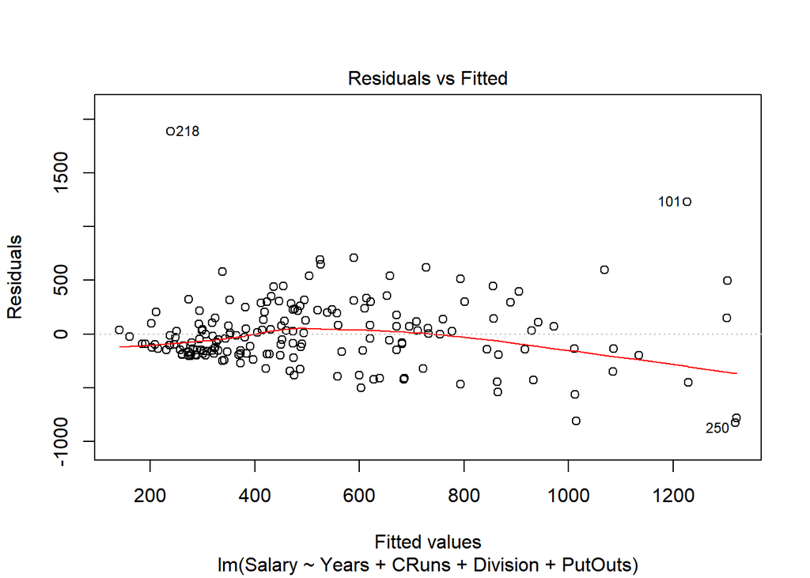

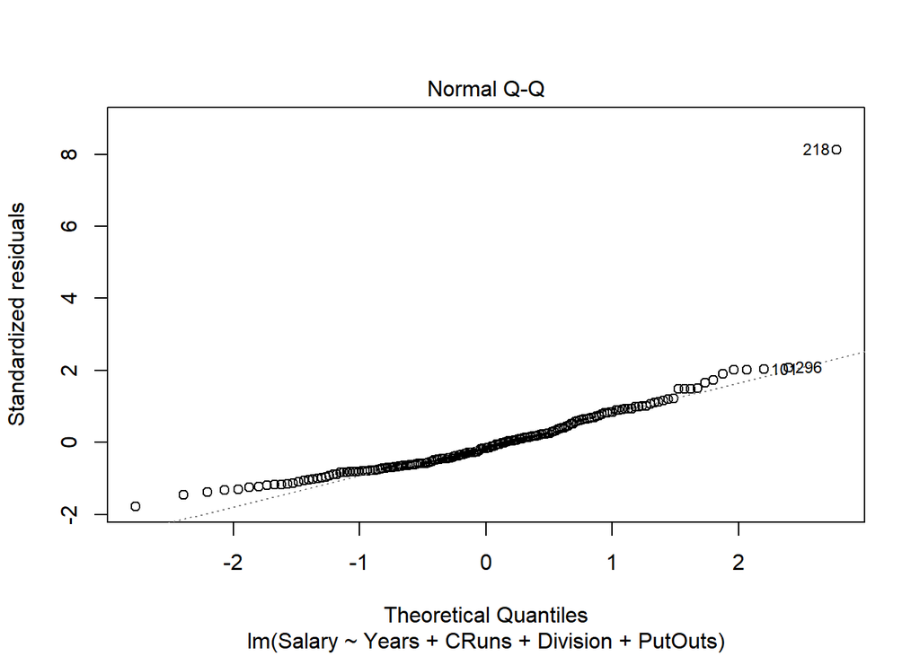

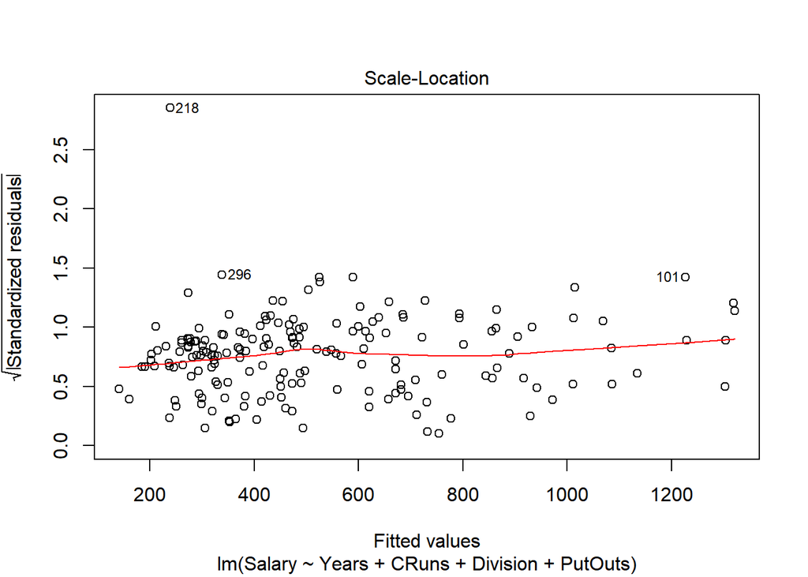

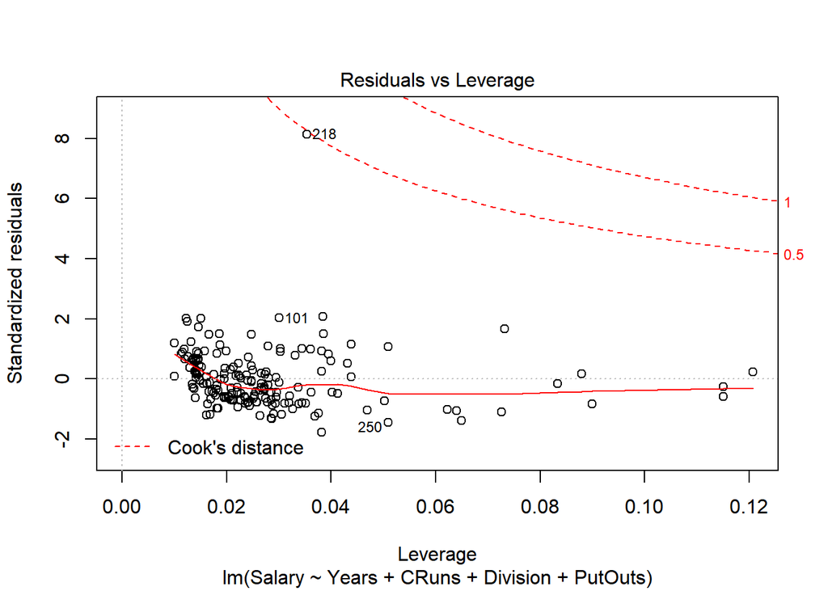

`r st.res5 <- model5$residuals / sd(model5$residuals)`

`r stats::ks.test(st.res5, y = "pnorm")`

`## ## One-sample Kolmogorov-Smirnov test ## ## data: st.res5 ## D = 0.11227, p-value = 0.02087 ## alternative hypothesis: two-sided`

`r car::ncvTest(model5)`

`## Non-constant Variance Score Test ## Variance formula: ~ fitted.values ## Chisquare = 4.553621, Df = 1, p = 0.032849` ###11. Modelde yer alan iki değişkene ait katsayıyı yorumlayınız.

`r summary(model5)`

`## ## Call: ## lm(formula = Salary ~ Years + CRuns + Division + PutOuts, data = train2, ## weights = wts) ## ## Weighted Residuals: ## Min 1Q Median 3Q Max ## -2.4406 -0.8952 -0.2156 0.7076 11.1677 ## ## Coefficients: ## Estimate Std. Error t value Pr(>|t|) ## (Intercept) 242.25505 52.69257 4.598 8.14e-06 *** ## Years -15.43905 9.14003 -1.689 0.0930 . ## CRuns 0.96909 0.16542 5.858 2.25e-08 *** ## DivisionW -77.41752 45.06075 -1.718 0.0875 . ## PutOuts 0.26978 0.09301 2.900 0.0042 ** ## --- ## Signif. codes: 0 '***' 0.001 '**' 0.01 '*' 0.05 '.' 0.1 ' ' 1 ## ## Residual standard error: 1.398 on 176 degrees of freedom ## Multiple R-squared: 0.3221, Adjusted R-squared: 0.3067 ## F-statistic: 20.9 on 4 and 176 DF, p-value: 4.083e-14`

`r model5$coefficients`

`## (Intercept) Years CRuns DivisionW PutOuts ## 242.2550484 -15.4390538 0.9690865 -77.4175208 0.2697802` Yorum: Katsayı anamlılığı:

Byears- değişkenim bir birim arttığında, diğer değişkenler modelde ve sabitken Maaş ortalama 15.4390 azalır.

BCRuns değişkenim bir birim arttığında ,diğer değişkenler modelde ve sabitken Salary ortalama 0.9690 artar.

PutOutputs değikenim bir birim arttığında diğer değişkenler modelde ve sabitken ortalama SAlary bağımlı değişkenim 0.2697802 artar.

### 12.Yeni bir gözlem değeri için %95’lik güven aralığını ve kestirim aralığını bularak yorumlayınız. (3 p.)

BCruns için yorum: CRuns bir birim arttığında , diğer değişkenler modelde ve sabitken Oyuncuların Maaşları %95 güvenle 0.64262225- 1.2955507 arasındadır.

Bputoutputs: PutOuts bir birim arttığında diğer değişkenler model de ve sabitken Oyuncuların maaşları %95 güvenle ortalama 0.08621687 - 0.4533435 değerleri arasındadır.

Yeni gözlem için test seti kullanılacaktır.

Tahmin değeri %95 güvenle lwr ve upr sütunlarındaki değerler arasında olacaktır.

```r
##X0 icin Y0'a ait tahmin araligi##
pred_confint1 <- predict(model5, test2, interval = "predict")
test_confint1 <- cbind(test2, pred_confint1)
head(test_confint)
```

```
##    Walks Years CAtBat CRuns CRBI CWalks Division PutOuts NewLeague  Salary
## 3     76     3   1624   224  266    263        W     880         A 480.000
## 4     37    11   5628   828  838    354        E     200         N 500.000
## 11    59    10   4631   702  504    488        E     238         A 517.143
## 13    47     4   1512   205  204    203        E     211         N 550.000
## 17    73    15   8068  1045  993    732        W     105         N 775.000
## 22    62     1    426    55   43     62        W     361         N 115.000
##         fit      lwr       upr
## 3  573.0023 438.8562  707.1484
## 4  928.7851 787.8269 1069.7433
## 11 832.3709 715.6715  949.0703
## 13 436.0852 362.1255  510.0449
## 17 974.2740 803.3287 1145.2193
## 22 300.0889 218.8385  381.3393
```

[output not shown]